# Crochet Patterns Using ggplot2

Juan Lozano Vallejo

2024-08-16

Given that recently I stumbled upon a lot of free time, I decided to go back to continue learning R, a tool that I used heavily a couple of years ago, but that have not used as much as I would like to recently.

After toying around with a couple of old scripts, I decided to focus my learning on two items: for loops and functions. When I was deciding on what project to embark to develop these skills, I came upon [Ryan McShane’s Crochet Patterns](https://blog.ryanmcshane.com/posts/2024-06-12-alternative-ggplot2-use-crochet-patterns/) via [R for the Rest of Us’s Newsletter](https://rfortherestofus.com/2024/07/whats-new-in-r-july-22-2024).

[figure not shown]

After playing with a couple of iterations of the code, I realized that I wanted to create a script that allowed me to produce n plots, each with randomly chosen colors for each of its components.

### The Process

With that in mind, I set out to work in R. The first step was to create a pool of three randomly generated colors, and then visualize them using the scales package. Since I am not setting a seed, the colors will change every time I run the script.

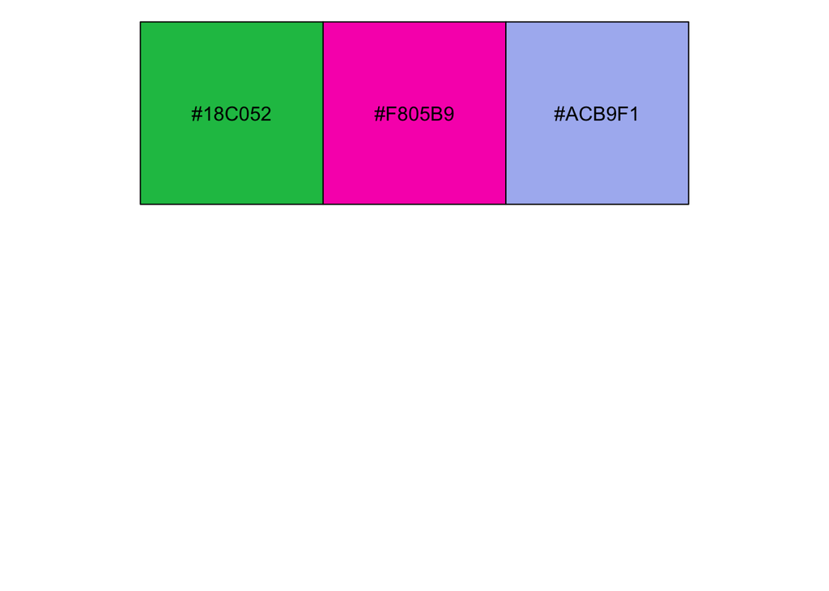

```r
# Loop to generate and store 3 random colors in separate values
for (i in 1:3) {
  color_name <- paste0("rc", i)
  assign(color_name, rgb(runif(1), runif(1), runif(1)))
}

# Print the colors to preview them
scales::show_col(c(rc1, rc2, rc3), ncol = 3)
```

Next, I needed to create a vector to store the colors, and three functions: one to pick one of the three colors; another to select two colors from the sample; and a third to select one option for the inner portion of the crochet pattern. This is needed to randomize as much as possible while maintaining some degree of aesthetic in the final product.

```r
# Create a vector with the colors to pick one at random later
rcolors <- c(rc1, rc2, rc3)

# Function to pick a random color from rcolors
pick_random_color <- function() {
  sample(rcolors, 1)
}

# Another function was needed to prevent colors repeating for both repetitions of mid and outer
pick_two_different_colors <- function() {
  colors <- sample(rcolors, 2, replace = FALSE)
}

# Create a function to pick one of the inner columns at random
pick_random_inner <- function() {
  sample(c('inner1', 'inner2', 'inner3', 'inner4', 'inner5'), 1)
}
```

The following step creates another function, this time to create a tibble that will allow to create plots with random colors for inner, mid, and outer layers in each iteration.

At this point I debated if I wanted to open the pool of colors, but decided to remain with only three after considering that the origins of the exercise was to help visualize how a crochet blanket would look like, and having a greater color variety could mean potential issued whilst procuring yarn.

```r
# Create a tibble using one random color picked at the start
create_flag_colors <- function() {
  tibble(
    inner1 = rep(pick_random_color(), 54),
    mid = rep(pick_two_different_colors(), 27),
    outer = rep(pick_two_different_colors(), 27),
    x = rep(1:6, each = 9),
    y = rep(1:9, times = 6),
    inner2 = rep(pick_random_color(), 54),
    inner3 = rep(pick_random_color(), 54),
    picker4 = sample(rep(c(1, 2), times = 27)),
    inner4 = if_else(picker4 == 1, outer, pick_random_color()),
    picker5 = rep(c(pick_random_color(), pick_random_color(), 'a', 'a'), times = 14)[1:54] |>
      matrix(nrow = 9, ncol = 6, byrow = TRUE) |>
      as.vector(),
    inner5 = if_else(picker5 == 'a', outer, pick_random_color())
  )
}
```

The next step is to create a function to create the plot with any established inner in the tibble. Not being a mathematician, I will not pretend to understand how Regular Pentagons work, thus I left the original function untouched.

```r
# Create a function for the patch plot
patch_plot <- function(data, inner, cons = 2.15, radius = 0.25){
  c1 = 0.25*(sqrt(5) - 1)*radius
  c2 = 0.25*(sqrt(5) + 1)*radius
  s1 = 0.25*(sqrt(10 + 2*sqrt(5)))*radius
  s2 = 0.25*(sqrt(10 - 2*sqrt(5)))*radius

  ggplot(data = data, aes(x = x, y = y, color = mid)) +
    geom_point(aes(color = outer), size = 16*cons, shape = 15) +
    geom_point(aes(y = y + radius), size = 5*cons) +
    geom_point(aes(x = x + s1, y = y + c1), size = 5*cons) +
    geom_point(aes(x = x + s2, y = y - c2), size = 5*cons) +
    geom_point(aes(x = x - s2, y = y - c2), size = 5*cons) +
    geom_point(aes(x = x - s1, y = y + c1), size = 5*cons) +
    geom_point(aes(color = .data[[inner]]), size = 4*cons) +
    scale_color_identity() +
    coord_fixed() +
    xlim(c(0.5, 6.5)) +
    ylim(c(0.5, 9.5)) +
    theme_void()
}
```

Lastly, it all comes to place when the patch plot function is ran to create the plots. I decided that `n=10` was a good amount of plots to have.

```r
# Generate and save 10 plots
plot_files <- vector('list', 10)
for (i in 1:10) {
  flag_colors <- create_flag_colors()  # Create flag colors for each plot
  p <- patch_plot(flag_colors, inner = pick_random_inner())
  plot_file <- paste0('ri', i, '.png')
  ggsave(plot_file, p, width = 6, height = 9)
  plot_files[[i]] <- plot_file
}
```

Once I had the 10 plots, I exported them as gif (some people pronounce it gif).

```r
 # Save as vector to ensure magick works
plot_files <- as_vector(plot_files)

# Use magick to combine the plots into an animated GIF
images <- image_read(plot_files)
animation <- image_animate(images, fps = 5)  # 5 frames per second

# Save the animated GIF
image_write(animation, 'ri.gif')
```

The complete script, including all versions of the scripts I created, can be found in the [GitHub repository](https://github.com/juanllave/patches).

### The End Result

The final product product is this very fast paced gif that I decided not to slow down nonetheless. While this is not the most aesthetically pleasing result, I did achieve my goals of improving my skills in creating functions and using for loops more comfortably.

```
## # A tibble: 10 × 7
##    format width height colorspace matte filesize density
##    <chr>  <int>  <int> <chr>      <lgl>    <int> <chr>
##  1 gif     1800   2700 sRGB       TRUE         0 118x118
##  2 gif     1800   2700 sRGB       TRUE         0 118x118
##  3 gif     1800   2700 sRGB       TRUE         0 118x118
##  4 gif     1800   2700 sRGB       TRUE         0 118x118
##  5 gif     1800   2700 sRGB       TRUE         0 118x118
##  6 gif     1800   2700 sRGB       TRUE         0 118x118
##  7 gif     1800   2700 sRGB       TRUE         0 118x118
##  8 gif     1800   2700 sRGB       TRUE         0 118x118
##  9 gif     1800   2700 sRGB       TRUE         0 118x118
## 10 gif     1800   2700 sRGB       TRUE         0 118x118
```

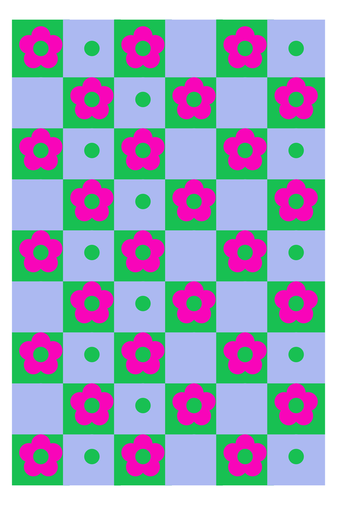

In next revisions, I might want to allow for more color variety in each iteration of the plot. I also might need to learn how regular pentagons work in order to create more crochet patterns. I might also want to take on crochet to be able to reproduce these patterns and be more comfortable at home once winter comes.